# Cyclistic Bikeshare Project

David Jeremiah

2022-07-12

## Background for Use Case

This is a report on how casual riders and annual members use Cyclistic bikes differently - a fictional bike-share company in Chicago. The director of marketing, Moreno, believes the company’s future success depends on maximizing the number of annual memberships.

From understanding how casual riders and annual members vary in their use of Cyclistic bikes, the marketing team can design a new marketing strategy to convert casual riders into annual members.

The original data was obtained from: [divvy-tripdata](https://divvy-tripdata.s3.amazonaws.com/index.html)

## Step 1: Setting up my environment

Notes: setting up my R environment by loading the needed packages

```r
library(tidyverse)
```

```r
library(skimr)
library(ggplot2)
library(assertive)
library(lubridate)
```

## Step 2: Importing and Viewing file

Notes: Using a sample from the entire file: *202101-divvy-tripdata*, for inspection

```r
print(head(sub_cylistic_data))
```

```
## # A tibble: 6 x 13
##   ride_id rideable_type started_at          ended_at            start_station_n~
##   <chr>   <chr>         <dttm>              <dttm>              <chr>
## 1 E19E6F~ electric_bike 2021-01-23 16:14:19 2021-01-23 16:24:44 California Ave ~
## 2 DC88F2~ electric_bike 2021-01-27 18:43:08 2021-01-27 18:47:12 California Ave ~
## 3 EC45C9~ electric_bike 2021-01-21 22:35:54 2021-01-21 22:37:14 California Ave ~
## 4 4FA453~ electric_bike 2021-01-07 13:31:13 2021-01-07 13:42:55 California Ave ~
## 5 BE5E8E~ electric_bike 2021-01-23 02:24:02 2021-01-23 02:24:45 California Ave ~
## 6 5D8969~ electric_bike 2021-01-09 14:24:07 2021-01-09 15:17:54 California Ave ~
## # ... with 8 more variables: start_station_id <chr>, end_station_name <chr>,
## #   end_station_id <chr>, start_lat <dbl>, start_lng <dbl>, end_lat <dbl>,
## #   end_lng <dbl>, member_casual <chr>
```

```r
print(skim_without_charts(sub_cylistic_data))
```

```
## -- Data Summary ------------------------
##                            Values
## Name                       sub_cylistic_data
## Number of rows             96834
## Number of columns          13
## _______________________
## Column type frequency:
##   character                7
##   numeric                  4
##   POSIXct                  2
## ________________________
## Group variables            None
##
## -- Variable type: character ----------------------------------------------------
##   skim_variable      n_missing complete_rate min max empty n_unique whitespace
## 1 ride_id                    0         1      16  16     0    96834          0
## 2 rideable_type              0         1      11  13     0        3          0
## 3 start_station_name      8625         0.911  10  51     0      640          0
## 4 start_station_id        8625         0.911   3  35     0      638          0
## 5 end_station_name       10277         0.894  10  53     0      632          0
## 6 end_station_id         10277         0.894   3  35     0      629          0
## 7 member_casual              0         1       6   6     0        2          0
##
## -- Variable type: numeric ------------------------------------------------------
##   skim_variable n_missing complete_rate  mean     sd    p0   p25   p50   p75
## 1 start_lat             0         1      41.9 0.0471  41.6  41.9  41.9  41.9
## 2 start_lng             0         1     -87.6 0.0271 -87.8 -87.7 -87.6 -87.6
## 3 end_lat             103         0.999  41.9 0.0471  41.6  41.9  41.9  41.9
## 4 end_lng             103         0.999 -87.6 0.0272 -87.8 -87.7 -87.6 -87.6
##    p100
## 1  42.1
## 2 -87.5
## 3  42.1
## 4 -87.5
##
## -- Variable type: POSIXct ------------------------------------------------------
##   skim_variable n_missing complete_rate min                 max
## 1 started_at            0             1 2021-01-01 00:02:05 2021-01-31 23:57:00
## 2 ended_at              0             1 2021-01-01 00:08:39 2021-02-01 15:33:15
##   median              n_unique
## 1 2021-01-15 06:05:04    93736
## 2 2021-01-15 06:19:58    93582
```

```
## $character
##
## -- Variable type: character ----------------------------------------------------
##   skim_variable      n_missing complete_rate min max empty n_unique whitespace
## 1 ride_id                    0         1      16  16     0    96834          0
## 2 rideable_type              0         1      11  13     0        3          0
## 3 start_station_name      8625         0.911  10  51     0      640          0
## 4 start_station_id        8625         0.911   3  35     0      638          0
## 5 end_station_name       10277         0.894  10  53     0      632          0
## 6 end_station_id         10277         0.894   3  35     0      629          0
## 7 member_casual              0         1       6   6     0        2          0
##
## $numeric
##
## -- Variable type: numeric ------------------------------------------------------
##   skim_variable n_missing complete_rate  mean     sd    p0   p25   p50   p75
## 1 start_lat             0         1      41.9 0.0471  41.6  41.9  41.9  41.9
## 2 start_lng             0         1     -87.6 0.0271 -87.8 -87.7 -87.6 -87.6
## 3 end_lat             103         0.999  41.9 0.0471  41.6  41.9  41.9  41.9
## 4 end_lng             103         0.999 -87.6 0.0272 -87.8 -87.7 -87.6 -87.6
## # ... with 1 more variable: p100 <dbl>
##
## $POSIXct
##
## -- Variable type: POSIXct ------------------------------------------------------
##   skim_variable n_missing complete_rate min                 max
## 1 started_at            0             1 2021-01-01 00:02:05 2021-01-31 23:57:00
## 2 ended_at              0             1 2021-01-01 00:08:39 2021-02-01 15:33:15
## # ... with 2 more variables: median <dttm>, n_unique <int>
```

Notes:

So, there are few issues in our data in need of wrangling.

## Step 3: Import complete wrangled dataset

Notes: spent some time working with and carrying out Data wrangling techniques on the individual spreadsheets. Then, imported each dataset and assigned them to individual variables: *divvy_tripdata_1 - divvy_tripdata_12*

## Step 4: Select needed columns for project

Here, we select the needed features for our project.

Notes: The following are the features we need for our casestudy:

- RIDE_ID
- RIDEABLE_TYPE
- USERTYPE
- START_DATE
- END_DATE
- START_TIME
- END_TIME
- START_STATION_NAME
- END_STATION_NAME
- RIDE_LENGTH
- WEEK_DAY

## Step 5: Merge Individual Spreadsheets into Full-year view

Here, we merge the wrangled individual spreadsheets into a full-year view for further analysis.

```r
full_dataset <- rbind(divvy_tripdata_1, divvy_tripdata_2, divvy_tripdata_3,
                      divvy_tripdata_4, divvy_tripdata_5, divvy_tripdata_6,
                      divvy_tripdata_7, divvy_tripdata_8, divvy_tripdata_9,
                      divvy_tripdata_10, divvy_tripdata_11, divvy_tripdata_12)
```

## Step 6i: Exploring Categorical data: USERTYPE count

Here, we make a count of the number of Casual riders against Annual members

```r
options(digits = 3)
perc_usertype <- full_dataset %>%
  summarize(percent_casual = mean(USERTYPE == "casual"),
            percent_annual = mean(USERTYPE == "member"))

print(sum(table(full_dataset$USERTYPE)))
```

```
## [1] 5595063
```

```r
print(perc_usertype)
```

```
## # A tibble: 1 x 2
##   percent_casual percent_annual
##            <dbl>          <dbl>
## 1          0.452          0.548
```

Notes: From the table, we see that Cyclistic bike_share company have a total of 5,595,063 users for the year, 2021, with more of annual members than casuals. Where 54.8 % are Annuals, 45.2% are Casuals.

The goal of Moreno, the director of marketing at Cyclistic, is to convert these **45.2%** to annuals.

## Visualizations

Here we would go through a series of visualizations

### Percent_annual per Month

Here, we visualize percentage of annual members for each month

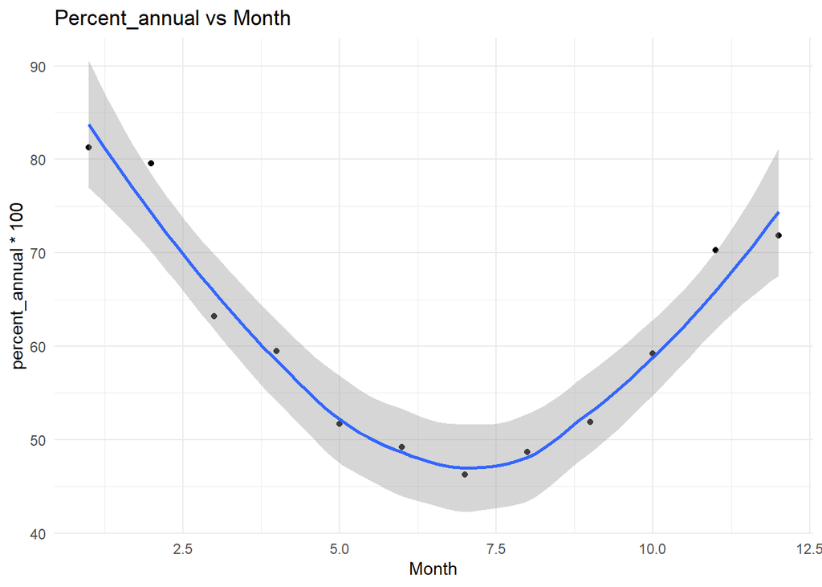

```r
print(perc_usertype_by_month %>%
        ggplot(aes(x = `month(START_DATE)`, y = percent_annual * 100)) +
        geom_point() +
        geom_smooth() +
        labs(title= 'Percent_annual vs Month', x = "Month") +
        theme_minimal())
```

### Percent_casual per Month

Here, we visualize percentage of casual members for each month

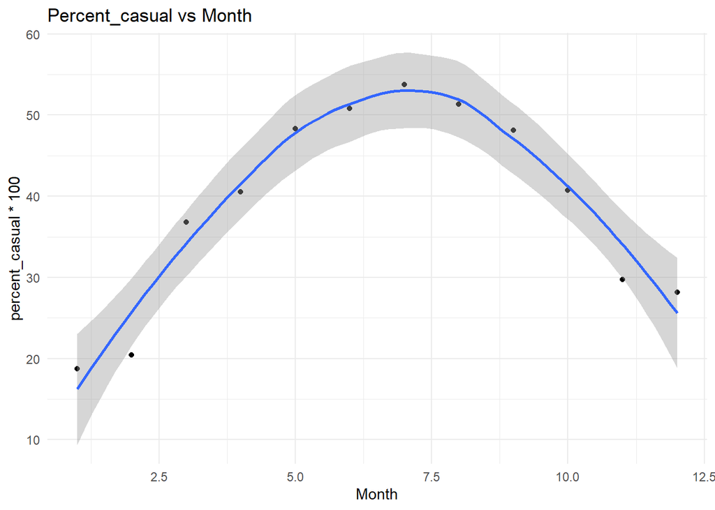

```r
print(perc_usertype_by_month %>%
        ggplot(aes(x = `month(START_DATE)`, y = percent_casual * 100)) +
        geom_point() +
        geom_smooth() +
        labs(title= 'Percent_casual vs Month', x = "Month") +
        theme_minimal())
```

### Proportion of Annuals and Casuals per Month

Here, we visualize percentage of annual and casual members for each month

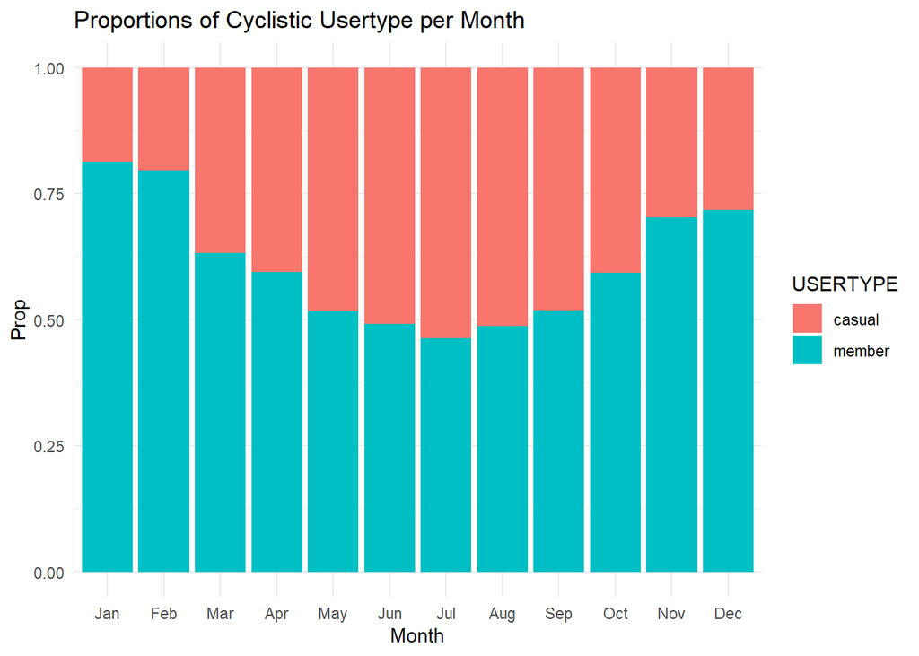

```r
print(full_dataset %>%
        ggplot(aes(x = month(START_DATE, label= TRUE),
                   fill = USERTYPE)) +
        geom_bar(position = "fill") +
        labs(title = "Proportions of Cyclistic Usertype per Month",
             x = "Month", y = "Prop") +
        theme_minimal())
```

Notes:

- From our result, we see that between September and May (i.e during autumn, winter, and spring seasons), Cyclistic bike-share system has highest percentage (> 50%) - i.e. highest number - of Annual members than Casuals.
- We also see that the highest number of annuals, are in the month of January. With the lowest being in the month of July. For Casuals, it was vice versa.

Next, let’s compare the proportions of Annuals and Casuals by week_day.

Note: weeks days count from Sunday (1) - Saturday (7)

### Percent_annual per Week day

Here, we visualize percentage of annual members for each Week Day

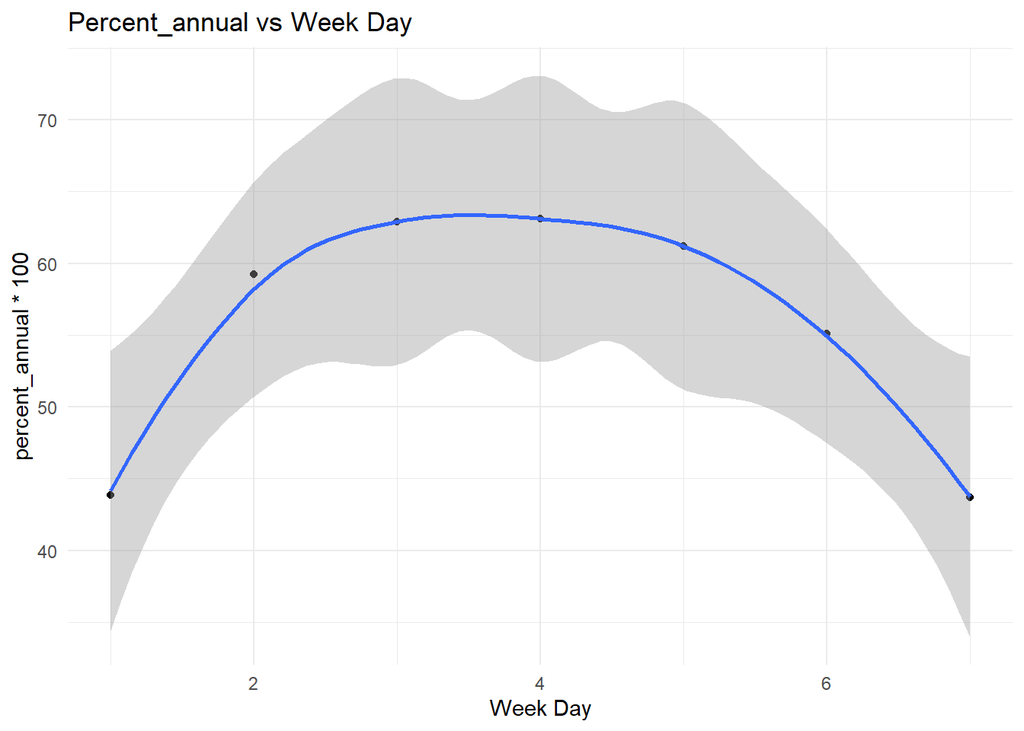

```r
print(perc_usertype_by_day %>%
        ggplot(aes(x = WEEK_DAY, y = percent_annual * 100)) +
        geom_point() +
        geom_smooth() +
        labs(title= 'Percent_annual vs Week Day', x = "Week Day") +
        theme_minimal())
```

### Percent_casual per Week day

Here, we visualize percentage of casual members for each Week Day

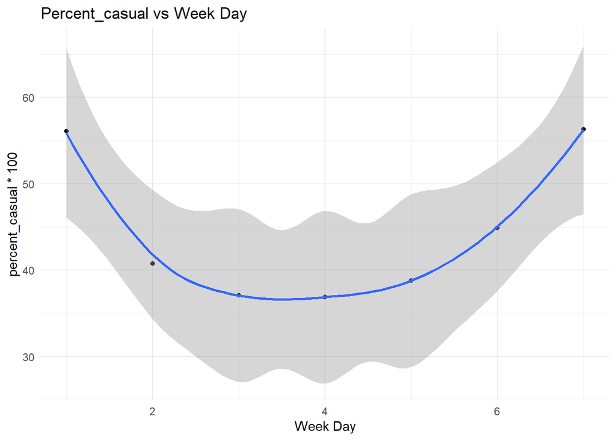

```r
print(perc_usertype_by_day %>%
        ggplot(aes(x = WEEK_DAY, y = percent_casual * 100)) +
        geom_point() +
        geom_smooth() +
        labs(title= 'Percent_casual vs Week Day', x = "Week Day") +
        theme_minimal())
```

### Proportion of Annuals and Casuals per Week Day

Here, we visualize percentage of annual and casual members for each week_day

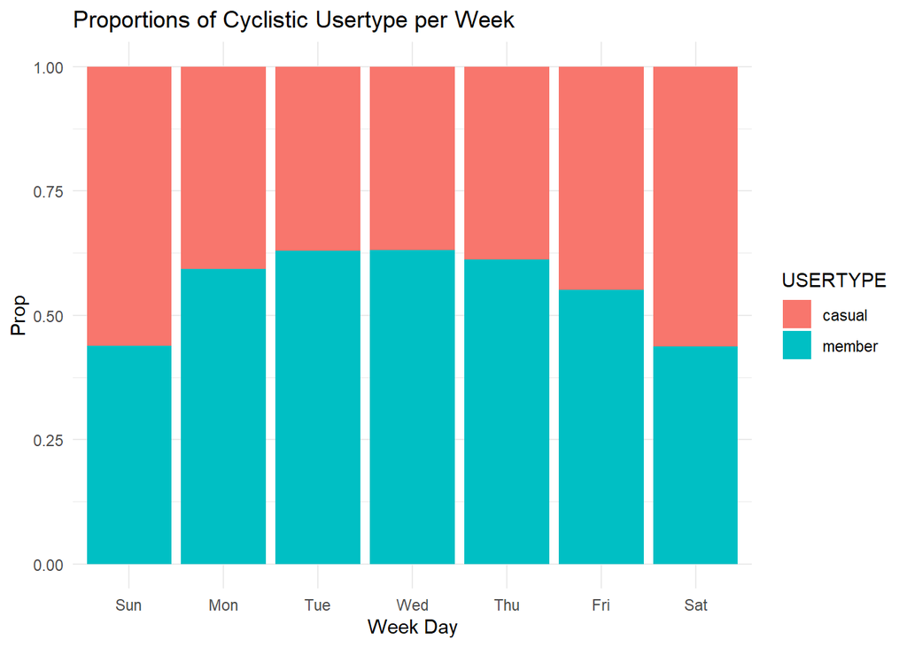

```r
print(full_dataset %>%
        ggplot(aes(x = wday(WEEK_DAY, label= TRUE),
                   fill = USERTYPE)) +
        geom_bar(position = "fill") +
        labs(title = "Proportions of Cyclistic Usertype per Week",
             x = "Week Day", y = "Prop") +
        theme_minimal())
```

Notes:

```
This suggests that most annual members use Cylistic bikes to commute to
work. Their peak patronage days being Tuesdays and Wednesdays. While most
Casual use Cylistic bikes mostly for leisure or recreational activities,
with peak patronage occurring in the weekends.

Furthermore, this goes on to highlight the reason why Annuals are highest
in January, as shown by our earliest plot of "Proportions of Cyclistic
Usertype per Month." This is possibly due to the start of a New year, with
majority of workers back from the holiday vacation, plus new hiring by
companies taking place.

For Casuals high number in July. This is probably due to the summer
vacation (as one factor), with students typically finishing the school
year between late-May and late-June, and starting the new year between
early-August and early-September.

Perhaps, the number of Casual patronage of Cyclistic bikes during summer
seasons are by students on break and mostly for leisure.
```

Next, let’s compare the proportions of Annuals and Casuals by both month and week_day

### Percent_annual for the Months and Days

Here, we visualize percentage of annual members for each Month and Day.

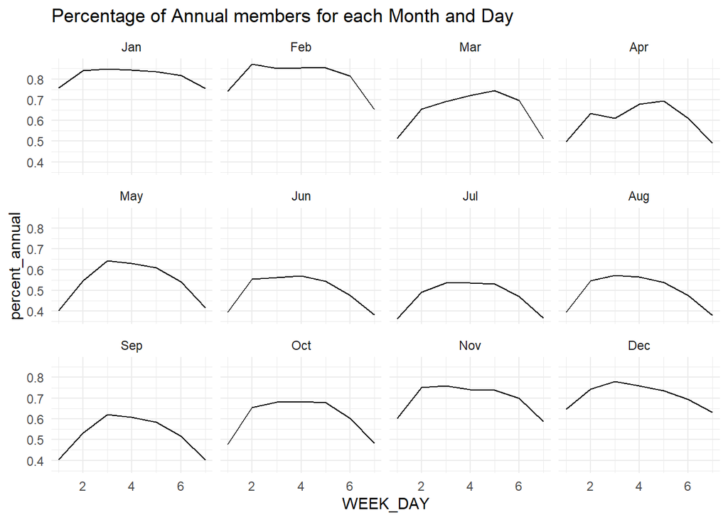

```r
print(perc_usertype_by_month_day %>%
        ggplot(aes(x = WEEK_DAY,
                   y = percent_annual)) +
        geom_line() +
        ggtitle(label = "Percentage of Annual members for each Month and Day") +
        facet_wrap(~ month(`month(START_DATE)`, label = TRUE)) +
        theme_minimal())
```

### Percent_casual per the Months and Days

Here, we visualize percentage of casual members for each Month and Day

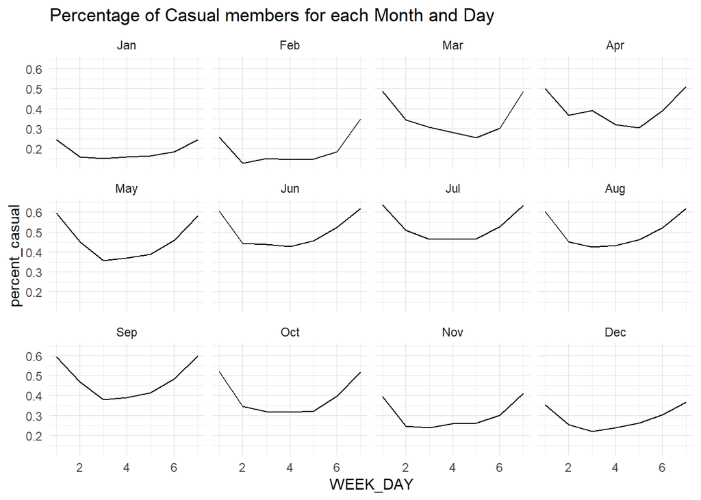

```r
print(perc_usertype_by_month_day %>%
        ggplot(aes(x = WEEK_DAY,
                   y = percent_casual)) +
        geom_line() +
        ggtitle(label = "Percentage of Casual members for each Month and Day") +
        facet_wrap(~ month(`month(START_DATE)`, label = TRUE)) +
        theme_minimal())
```

Notes:

- Generally, for casuals, they patronize Cyclistic bikes more, in all the months of the year, during weekends than on working days. And this is at its peak as they approach Summer: June, July, and August.
- For Annuals, they patronize Cyclistic bikes more in all the months during working days than on weekends. And this dwindles as they approach summer but picks up during Winter, Spring and Autumn seasons.

## Step 6ii: Exploring Categorical data: USERTYPE vs RIDEABLE_TYPE

Here, we check the types of bikes commonly used by Casual or Annual members

```r
tb_cnt_ut_rt <- table(full_dataset$RIDEABLE_TYPE, full_dataset$USERTYPE)
print(prop.table(tb_cnt_ut_rt, 1))
```

```
##
##                   casual   member
##   classic_bike  3.90e-01 6.10e-01
##   docked_bike   1.00e+00 3.20e-06
##   electric_bike 4.68e-01 5.32e-01
```

## Visualizations

Here we would go through a series of visualizations

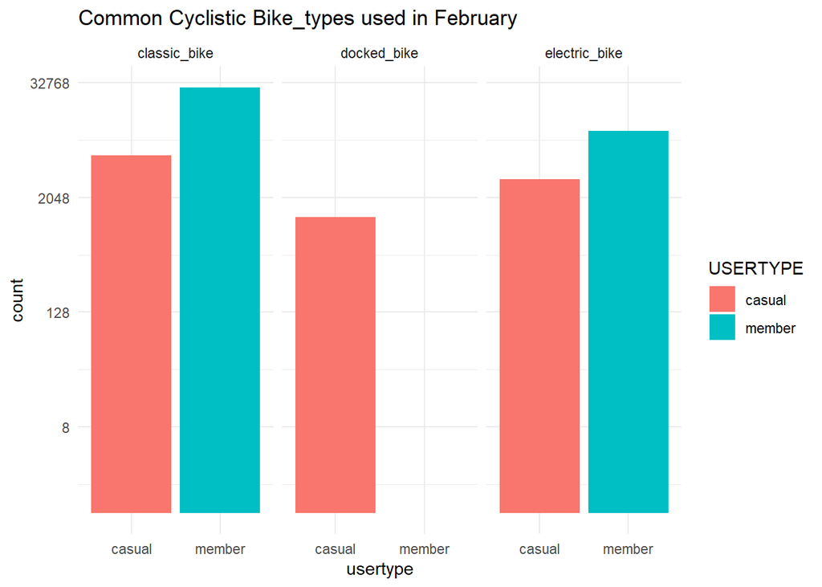

```r
print(full_dataset %>%
        filter(month(START_DATE) == 02) %>%
        ggplot(aes(x = USERTYPE, fill = USERTYPE)) +
        geom_bar(position = "dodge") +
        labs(title = "Common Cyclistic Bike_types used in February", x = "usertype") +
        scale_y_continuous(trans = "log2") +
        facet_wrap(~RIDEABLE_TYPE) +
        theme_minimal())
```

Notes: We already know that there are infact three possible rideable types: **‘classic_bike’**, **‘docked_bike’**, and **‘electric_bike’** in our dataset.

So, first, the analysis tells us that the most common bike used by both types of riders - Annuals and Casuals - are classic bikes.

However, when comparing by proportions, classic_bikes are used more by annual members than by casual members: **61% vs 39%.**

The next bike commonly used are electric bikes, with annual member using more of it than casual members: **53.2% vs 46.8%**

Interestingly, more casual users than annual members opt for docked bikes (**100% vs < 0.05%**). It seems as though hardly do annuals used these types of bikes. However, note that, Casuals use docked bikes less, compared to the other types of Cyclistic bikes.

```
Note: With this summary, since a large proportion of Annuals use cyclistic
bikes to commute to work, it translates to mean a large percentage of
classic and electric bikes used by Annuals, are for work purposes, than
for recreational purposes.

In the same way, since a large proportion of Casuals use cyclistic bikes
for leisure, it translates to mean large percentage of classic, electric,
and docked bikes used by Casuals, are for recreational purposes, than for
work purposes.
```

Questions to consider:

- Which bikes is preferred more by Casuals for recreational purpose?
- Which bikes is preferred more by Annuals for recreational purpose?

### Facet by rideable_type and month

Apparently, our analysis holds true for 10 months from December. Let’s see if that’s the case in the eleventh month, by comparing February with November

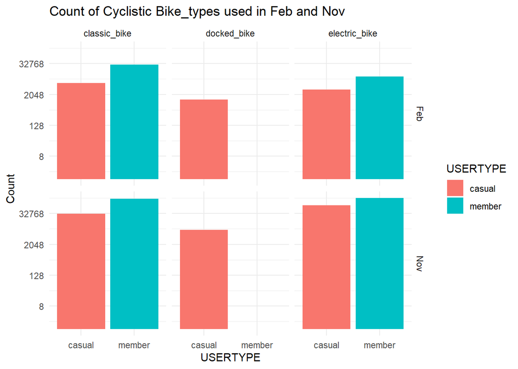

```r
print(full_dataset %>%
        filter(month(START_DATE) %in% c(02, 11)) %>%
        ggplot(aes(x = USERTYPE, fill = USERTYPE)) +
        geom_bar(position = "dodge") +
        labs(title = "Count of Cyclistic Bike_types used in Feb and Nov",
             y = "Count") +
        facet_grid(month(START_DATE, label = TRUE) ~ RIDEABLE_TYPE) +
        scale_y_continuous(trans = 'log2') +
        theme_minimal())
```

Notes: From our plot, we find that while majority of Casuals have increased in their use of classic and electric bikes over the months from February. Yet, Annuals subscribe for it more.

We also see that Casuals have maintained an increase use of docked bikes over the months.

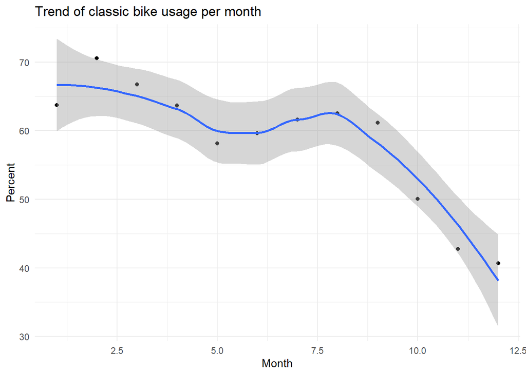

```r
print(bike_used_per_month %>%
        ggplot(aes(x = `month(START_DATE)`, y = percent_classic * 100)) +
        geom_point() +
        geom_smooth() +
        labs(title = "Trend of classic bike usage per month",
             x = "Month", y = "Percent") +
        theme_minimal())
```

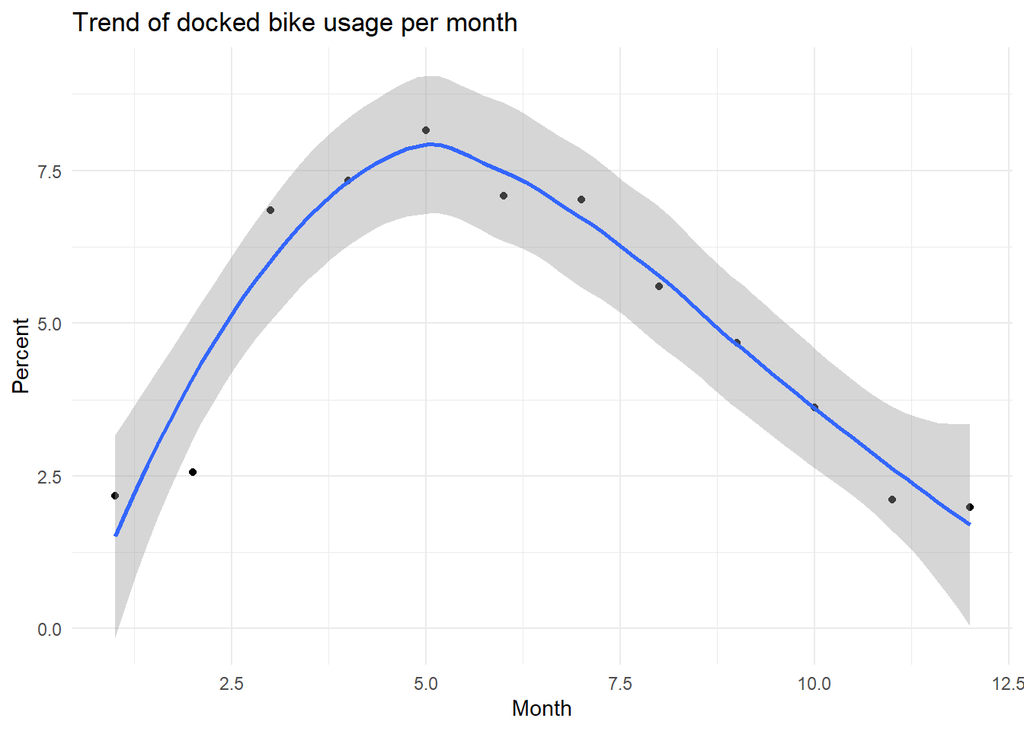

```r
print(bike_used_per_month %>%
        ggplot(aes(x = `month(START_DATE)`, y = percent_docked * 100)) +
        geom_point() +
        geom_smooth() +
        labs(title = "Trend of docked bike usage per month",
             x = "Month", y = "Percent") +
        theme_minimal())
```

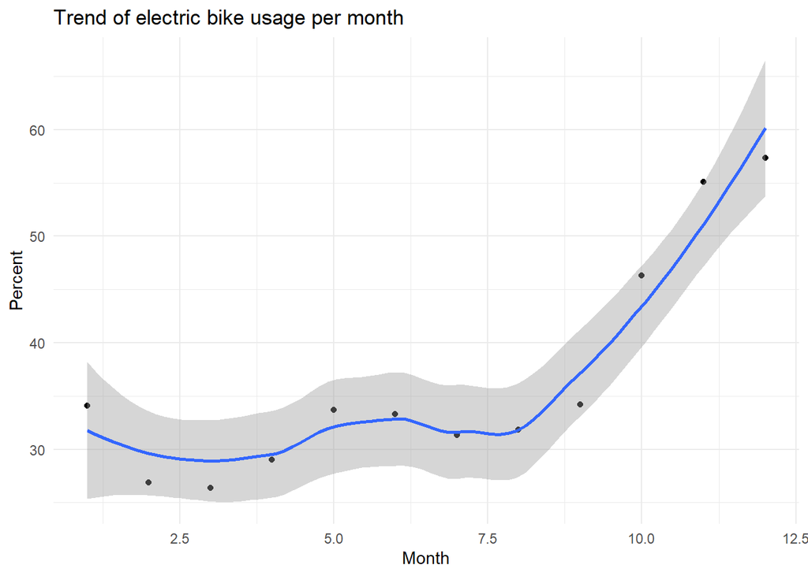

```r
print(bike_used_per_month %>%
        ggplot(aes(x = `month(START_DATE)`, y = percent_electric * 100)) +
        geom_point() +
        geom_smooth() +
        labs(title = "Trend of electric bike usage per month",
             x = "Month", y = "Percent") +
        theme_minimal())
```

```
A. This shows that there is a linear relationship between the use
of classic bikes and electric bikes across the months of the year.
(Check out the scatter plot below to confirm this)

B. This also shows that both Annuals and Casuals prefer to use Classic
bikes in the first 8 months of the year than electric bikes.
However, there are some casuals that opt for docked bikes instead.
```

Questions to consider:

1. What factors influence this trend for Casuals - their choice of bikes in these months: Time Availability of Bikes, Stations of Bikes, Speed of Bikes, Seasons??

Docked bikes are used more, together with classic bikes somewhere in the beginning and middle of the year - between March and August.

```
c. This shows that Casual riders prefer to use more of Classic bikes
and Docked bikes for recreational purposes during the winter, spring, and
summer seasosn. And giving that their use of classic bikes is greater than
docked bikes, we can say they seem to prefer to ride classic bikes, during
these periods for leisure.
```

### Scatter plot

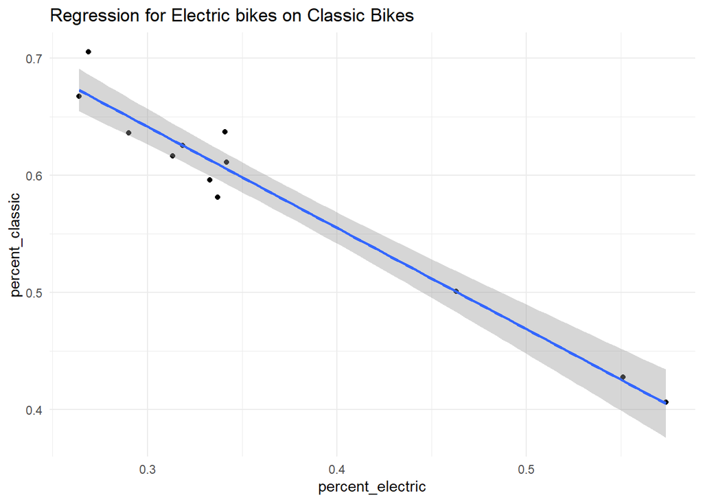

```r
print(bike_used_per_month %>%
        ggplot(aes(x = percent_electric,
                   y = percent_classic)) +
        geom_point() +
        geom_smooth(method = lm) +
        labs(title = "Regression for Electric bikes on Classic Bikes") +
        theme_minimal())
```

Notes: From our plot, we see a negative linear relationship between the use of classic bikes and electric bikes across the year.

We see that as the use of classic bikes decreases in their patronage across the year, the use of electric bikes increases.

Question to consider:

- WHY is there a negative linear relationship between classic bikes and electric bikes across the months of the year?

Now, let’s check common bikes used per day_of_week

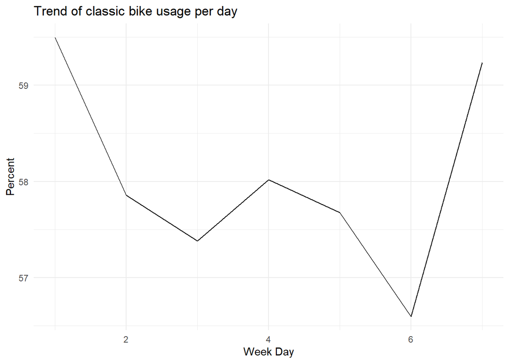

```r
print(bike_used_per_day %>%
        ggplot(aes(x = WEEK_DAY, y = percent_classic * 100)) +
        geom_line() +
        labs(title = "Trend of classic bike usage per day",
             x = "Week Day", y = "Percent") +
        theme_minimal())
```

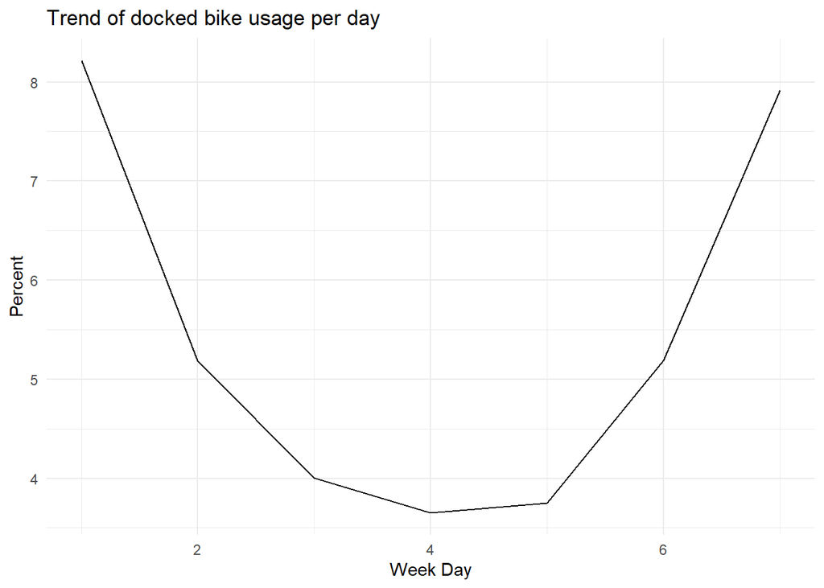

```r
print(bike_used_per_day %>%
        ggplot(aes(x = WEEK_DAY, y = percent_docked * 100)) +
        geom_line() +
        labs(title = "Trend of docked bike usage per day",
             x = "Week Day", y = "Percent") +
        theme_minimal())
```

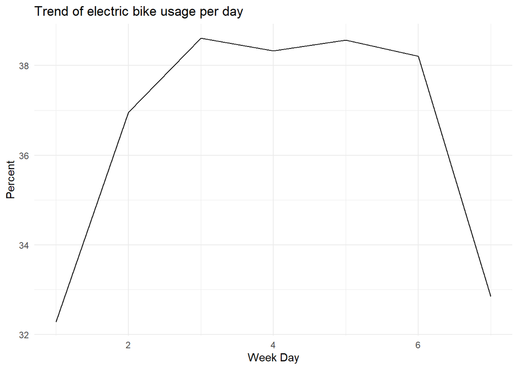

```r
print(bike_used_per_day %>%
        ggplot(aes(x = WEEK_DAY, y = percent_electric * 100)) +
        geom_line() +
        labs(title = "Trend of electric bike usage per day",
             x = "Week Day", y = "Percent") +
        theme_minimal())
```

Now, let check the types of bikes commonly used in each months and week_day

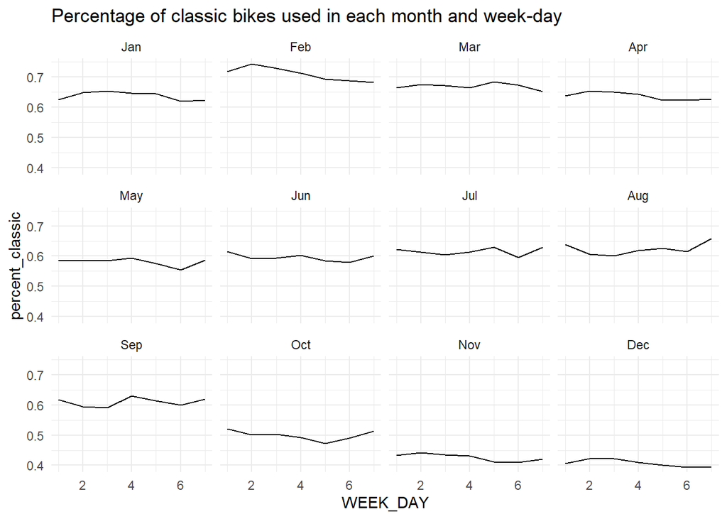

```r
print(bike_used_per_month_day %>%
        ggplot(aes(x = WEEK_DAY,
                   y = percent_classic)) +
        geom_line() +
        ggtitle(label = "Percentage of classic bikes used in each month and week-day") +
        facet_wrap(~ month(`month(START_DATE)`, label = TRUE)) +
        theme_minimal())
```

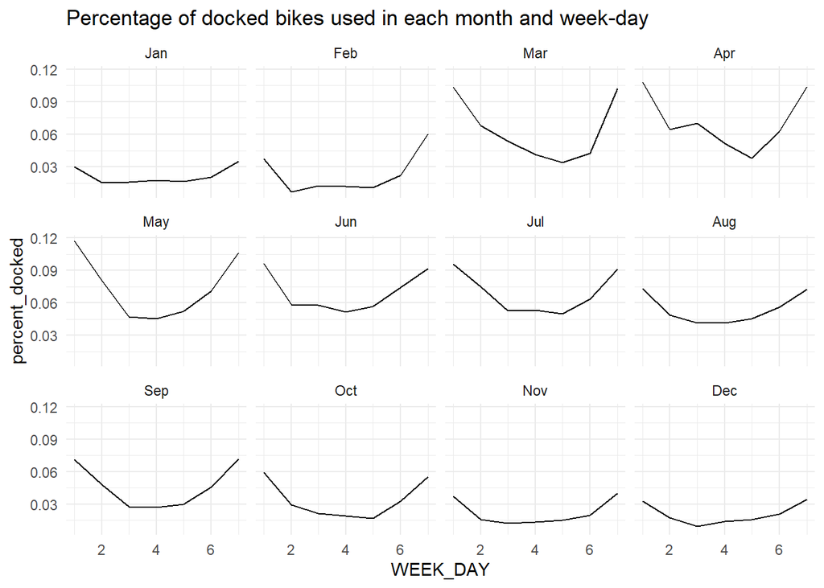

```r
print(bike_used_per_month_day %>%
        ggplot(aes(x = WEEK_DAY,
                   y = percent_docked)) +
        geom_line() +
        ggtitle(label = "Percentage of docked bikes used in each month and week-day") +
        facet_wrap(~ month(`month(START_DATE)`, label = TRUE)) +
        theme_minimal())
```

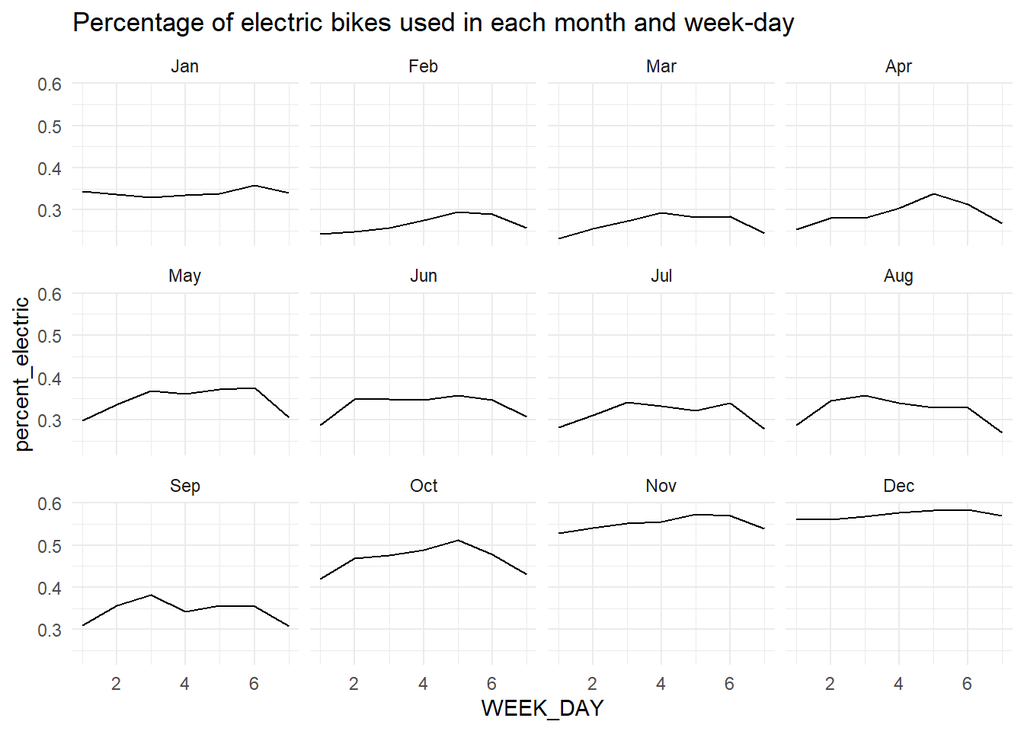

```r
print(bike_used_per_month_day %>%
        ggplot(aes(x = WEEK_DAY,
                   y = percent_electric)) +
        geom_line() +
        ggtitle(label = "Percentage of electric bikes used in each month and week-day") +
        facet_wrap(~ month(`month(START_DATE)`, label = TRUE)) +
        theme_minimal())
```

Notes:

In General, considering the first and last days, classic_bikes are used more on weekends than business days. Although, when compared to other bike types, it is used during the business days more. And they are patronized more from the Winter to Summer Season.

Docked bikes, for all the months, are also used more during weekends than business days. However, they are patronized in high proportion, from the Spring entering into the Summer season.

Electric bikes, however are used less during the weekends, but more during business days. And they are being sort after and use as we approach the holidays.

## Step 7: Exploring Numerical data

### Descriptive Statistical Analysis

Here, we group by USERTYPE, and calculate the mean, maximum value, minimum_value, median, standard_deviation, mode, and IQR of RIDE_LENGTH feature

```r
summary_user_ridelengths <- full_dataset %>%
  group_by(USERTYPE) %>%
  summarize(count = n(),
            mean = mean(RIDE_LENGTH, na.rm = TRUE),
            std_dev = sd(RIDE_LENGTH, na.rm = TRUE),
            min = min(RIDE_LENGTH, na.rm = TRUE),
            median = median(RIDE_LENGTH, na.rm=TRUE),
            mode = mode(RIDE_LENGTH, na.rm= TRUE),
            iqr = IQR(RIDE_LENGTH, na.rm = TRUE),
            max = max(RIDE_LENGTH, na.rm = TRUE))

print(summary_user_ridelengths)
```

```
## # A tibble: 2 x 9
##   USERTYPE   count  mean std_dev   min median  mode   iqr   max
##   <chr>      <int> <dbl>   <dbl> <dbl>  <dbl> <dbl> <dbl> <dbl>
## 1 casual   2529005  32.0   263.    -58     16     8    20 55944
## 2 member   3066058  13.6    27.7   -54     10     5    11  1560
```

### Average ride_length for members and casual riders

Here, we visualize the average ride_length for members and casual riders

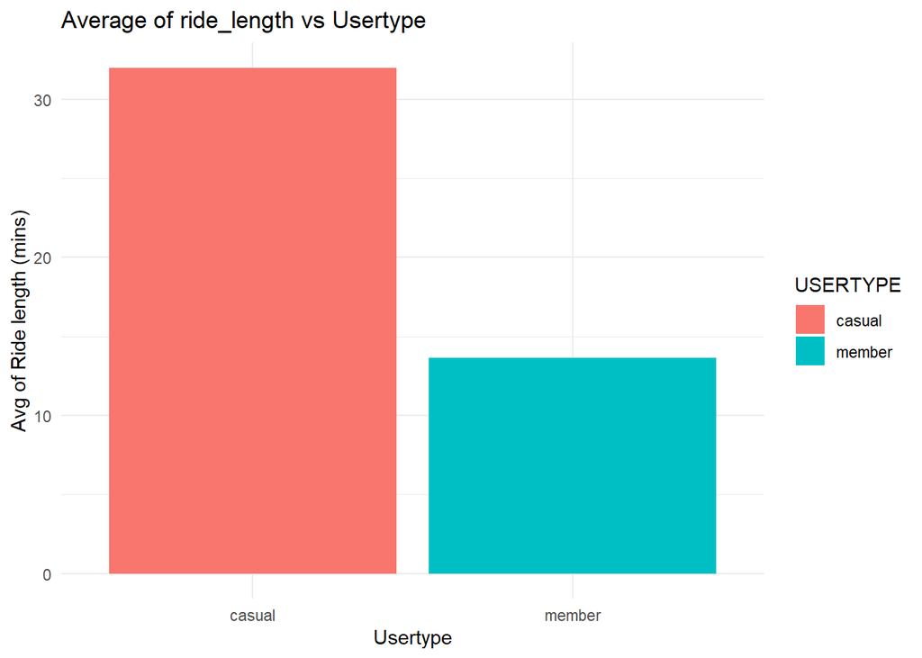

```r
print(summary_user_ridelengths %>%
        ggplot(aes(x= USERTYPE, y=as.numeric(mean), fill=USERTYPE)) +
        geom_col() +
        labs(title = "Average of ride_length vs Usertype",
             x = "Usertype",
             y = "Avg of Ride length (mins)") +
        theme_minimal())
```

Notes:

1. From the table, we reaffirm that we have more annual members than casual members.
2. However, on average, casual members ride for longer hours/mins than annual members: 32 mins vs 13.6 mins
3. In summary the highest ride_lengths (in mins for 2021) are from casual members (55,944 mins) compared to annual members (1,560 mins).
4. Also, the most common ride_lengths for casual members per day is 8 mins on average. For annuals, it’s 5 mins.

Questions to consider:

- What could be the reason casuals ride for long mins/hours and Annuals ride for less?
- What factors influence the long rides for Casuals and short rides for Annuals?
- Could it be as a result of Season/Weather of the year, far distance to cover, type of activity they do, type of ride?
- Does the day of the week impact the length of ride?
- Does the month impact the length of ride?
- Does the same factor affect annual members?

### Average ride_length for users by Month.

Here, we calculate and visualize the average ride_length for users by Month.

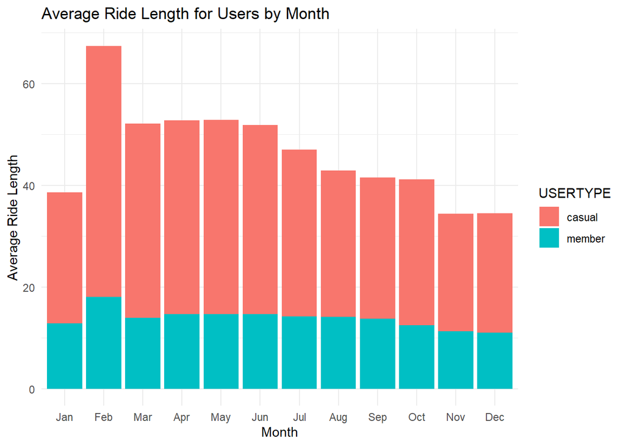

```r
print(avg_ridelength_by_month %>%
        ggplot(aes(x = month(`month(START_DATE)`, label = TRUE),
                   y = mean,
                   fill = USERTYPE)) +
        geom_col() +
        labs(title = "Average Ride Length for Users by Month",
             x = "Month",
             y = "Average Ride Length") +
        theme_minimal())
```

Notes:

1. From the graph, it’s clear that casuals ride longer hours/mins than Annuals all through the year. Annuals tend to have shorter and steady rides.
2. We also notice that Casuals and Annuals highest rides between February up until October, where it begins to decline as we enter the holiday periods: November - January. This is predominantly the winter seasons.

   So, evidently, the weather condition influences the length of rides for both users. Giving that the weather during the winter season is general windy, cold, and frozen, many users would choose to use alternate transit than bikes. Hence, the reduction in ride_lengths during these months.

   But as the winter ends (somewhere in February), and we approach the spring, summer, and autumn seasons, which have more pleasant weather conditions (in comparison to the Winter) for bike riding.

In general, many people are inspired to use cyclistic bike share system under pleasant expected weather conditions.

### Average ride_length for users by day_of_week

Here, we calculate and visualize the average ride_length for users by Day of Week

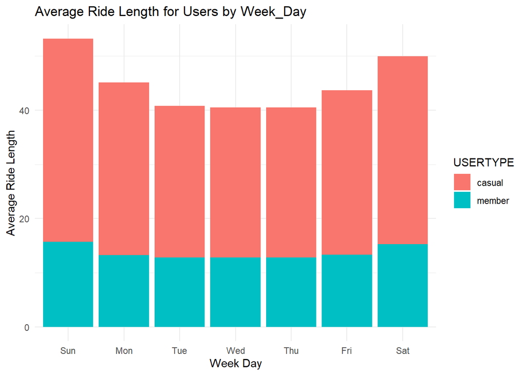

```r
print(avg_ridelength_by_wday %>%
        ggplot(aes(x = wday(WEEK_DAY, label = TRUE),
                   y = mean,
                   fill = USERTYPE)) +
        geom_col() +
        labs(title = "Average Ride Length for Users by Week_Day",
             x = "Week Day", y = "Average Ride Length") +
        theme_minimal())
```

Notes:

1. For casual members, they ride more during the weekends: Saturday’s and Sunday’s. And this appears to be the same for annuals members. In other words, there are more rides during the weekends than the business days.
2. The day with the lowest ride_length for each usertype are the business days. However, when you compare Casual ride_lengths on working days, they are still higher than Annuals.

   Note: Considering that majority of Casuals use Cyclistic bikes for leisure or recreational purposes than simply commuting to work as the Annuals, hence it explains why they have longer ride_lengths than Annuals - whose ride-length are steady and shorter - during the working days.

In general, bikes used for recreational activities have lesser time constraints, than when used simply to punch a timeline as it is with those commuting strictly to work.

Now let’s see if there is a relationship between type of rides and ride length

### Relationship between type of rides and ride length

Here, we calculate and visualize the average ride_length (mins) and observe how they differ between different “Rideable_type”

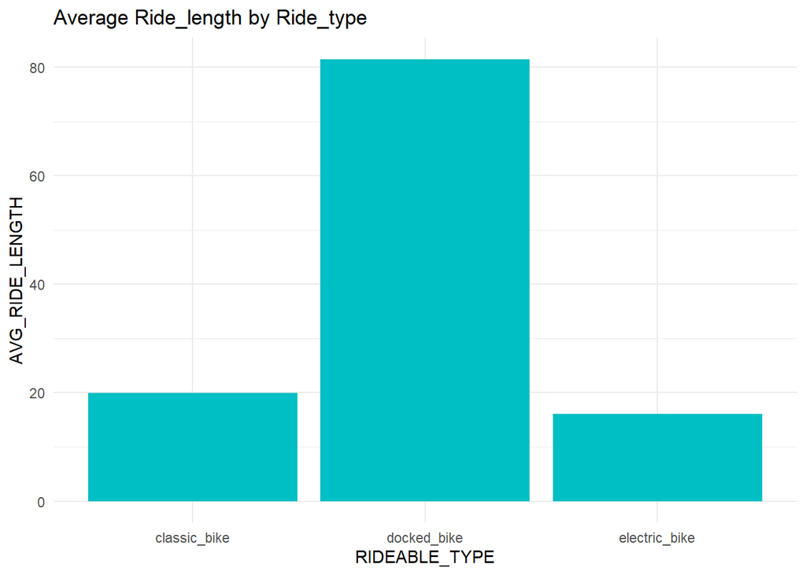

```r
print(avg_ridelength_by_ridetype %>%
        ggplot(aes(x = RIDEABLE_TYPE, y = AVG_RIDE_LENGTH)) +
        geom_bar(fill = "#00BFC4", stat = "identity") +
        ggtitle("Average Ride_length by Ride_type") +
        theme_minimal())
```

Notes:

1. From the table and plot, docked bikes have longer ride_lengths (81.5 mins) on average, compared to classic_bikes (19.9 mins), and electric_bikes (16 mins).

   One would have assumed that docked_bike longer ride lengths are due to it being used often by Casuals. But, giving that Docked bikes are used the least by Casuals in comparison to Classic bikes based on our analysis above, the result in the graph thus implies that this deals with the speed of the bikes.

```
In general, one of factors influencing longer ride_lengths with Casuals
and fewer with Annuals is: the bike_type speed.

We already know that Annuals use more of Classic and Electric bikes.
Hence, giving that these two are fast-paced bikes, they commute to their
destination for less hour/min.

On the other hand, giving that Casuals use more of classic_bikes and
docked_bikes, with much of their use during the first eight months of the
year, it explains why our plot shows long_bike lengths (for casuals)
during the first 8 months as well, compared to the last four months.
```

```r
avg_ridelength_by_month_ridetype <- full_dataset %>%
  group_by(RIDEABLE_TYPE, month(START_DATE)) %>%
  summarize(AVG_RIDE_LENGTH = mean(as.numeric(RIDE_LENGTH), na.rm = T))
```

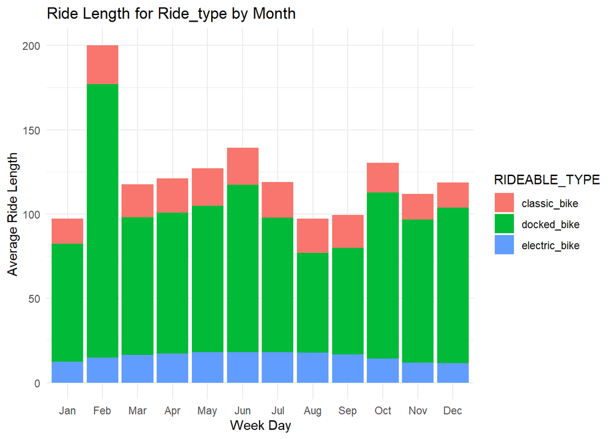

```r
print(avg_ridelength_by_month_ridetype %>%
        ggplot(aes(x = month(`month(START_DATE)`, label = TRUE),
                   y = AVG_RIDE_LENGTH,
                   fill = RIDEABLE_TYPE)) +
        geom_col() +
        labs(title = "Ride Length for Ride_type by Month",
             x = "Week Day", y = "Average Ride Length") +
        theme_minimal())
```

Now, let’s see if there is a relationship between count of usertype and rideable_type by Cyclistic bike stations

### Relationship between Usertype and Rideable_type by Station

Here, we want to know if there a relationship between the count of Rideable_type available per station and the use of Rideable_type

For example, We already know that Casual riders patronize docked bikes more than Annuals.

- Why is this the case?
- Could it be there are more docked_bike near-by stations where casuals are located (as one is likely to rent a bike with the bike-share station nearest to him or her)?
- Are annuals located closely to classic_bike and electric_bike stations. Does that influence why thy use more of these bikes, besides their speed, to commute to work faster?

#### Determine the start stations with the highest number for each rideable_type

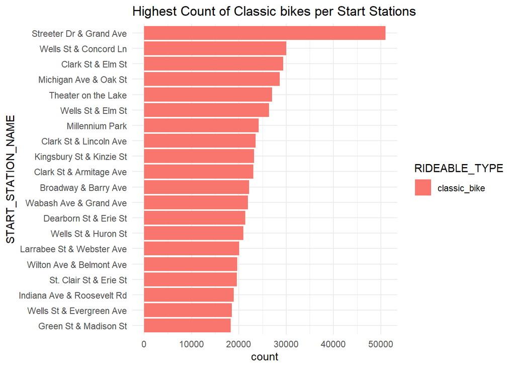

```r
print(head(startstationame_by_ridetype %>%
             filter(RIDEABLE_TYPE == "classic_bike") %>%
             mutate(START_STATION_NAME = reorder(START_STATION_NAME, count)), 20) %>%
        ggplot(aes(x = START_STATION_NAME, y = count, fill = RIDEABLE_TYPE)) +
        geom_col(position = "stack") +
        coord_flip() +
        ggtitle(label = "Highest Count of Classic bikes per Start Stations" ) +
        theme_minimal())
```

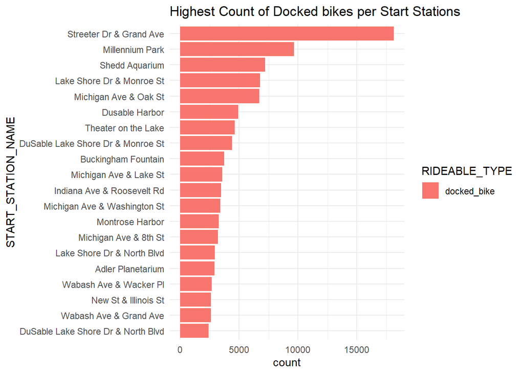

```r
print(head(startstationame_by_ridetype %>%
             filter(RIDEABLE_TYPE == "docked_bike") %>%
             mutate(START_STATION_NAME = reorder(START_STATION_NAME, count)), 20) %>%
        ggplot(aes(x = START_STATION_NAME, y = count, fill = RIDEABLE_TYPE)) +
        geom_col(position = "stack") +
        coord_flip() +
        ggtitle(label = "Highest Count of Docked bikes per Start Stations" ) +
        theme_minimal())
```

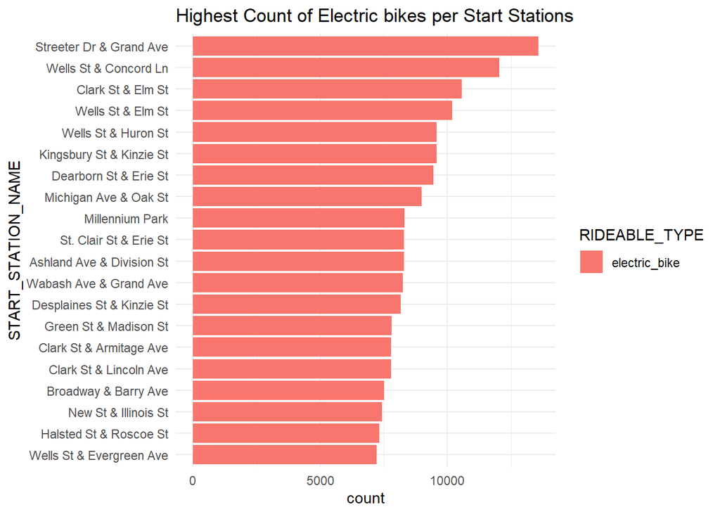

```r
print(head(startstationame_by_ridetype %>%
             filter(RIDEABLE_TYPE == "electric_bike") %>%
             mutate(START_STATION_NAME = reorder(START_STATION_NAME, count)), 20) %>%
        ggplot(aes(x = START_STATION_NAME, y = count, fill = RIDEABLE_TYPE)) +
        geom_col(position = "stack") +
        coord_flip() +
        ggtitle(label = "Highest Count of Electric bikes per Start Stations" ) +
        theme_minimal())
```

Now, let’s see if there is a relationship between number of user_type and Cyclistic bike start stations

#### Determine the start stations with the highest number of casual or annual users

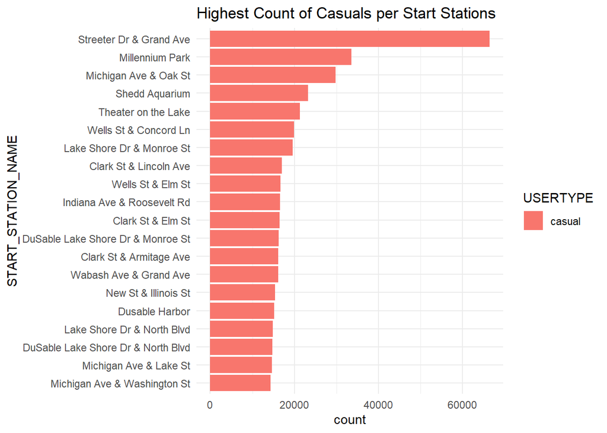

```r
print(head(startstationame_by_usertype %>%
             filter(USERTYPE == "casual") %>%
             mutate(START_STATION_NAME = reorder(START_STATION_NAME, count)), 20) %>%
        ggplot(aes(x = START_STATION_NAME, y = count, fill = USERTYPE)) +
        geom_col(position = "stack") +
        coord_flip() +
        ggtitle(label = "Highest Count of Casuals per Start Stations" ) +
        theme_minimal())
```

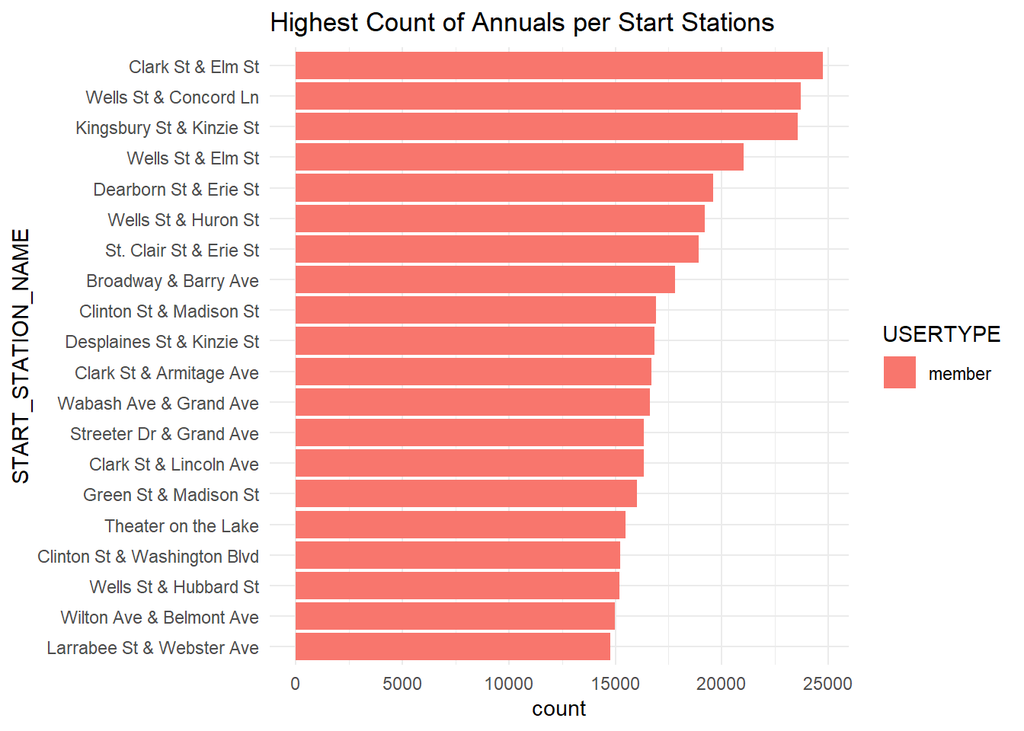

```r
print(head(startstationame_by_usertype %>%
             filter(USERTYPE == "member") %>%
             mutate(START_STATION_NAME = reorder(START_STATION_NAME, count)), 20) %>%
        ggplot(aes(x = START_STATION_NAME, y = count, fill = USERTYPE)) +
        geom_col(position = "stack") +
        coord_flip() +
        ggtitle(label = "Highest Count of Annuals per Start Stations" ) +
        theme_minimal())
```

Notes:

1. From the result, the start_station with the highest count of classic_bikes, electric_bikes, and docked_bikes is **‘Streeter Dr & Grand Ave’**
2. We also observe, from the plots above, that by comparing the counts of Casuals per start stations, we see that majority of casuals (**> 20,000**) are located closely to start stations where they have high counts of docked bikes. For example, *Streeter Dr & Grand Ave*, *Millennium Park*, *Shedd Aquarium*, *Theather on the Lake*, etc.
3. Similarly, we observe, from the plots above, that by comparing the counts of Annuals per start stations, we see that majority of Annuals (**> 20,000**) are located away from docked_bike start stations, but are found close to start stations with high counts of electric and classic bikes. For example, *Clark St & Elm St.*, *Wells St & Concord Ln*, *Kingsbury St & Kinzie St*, and *Wells St & Elm St*

Now, let’s consider end stations

#### Determine the end stations with the highest number for each rideable_type

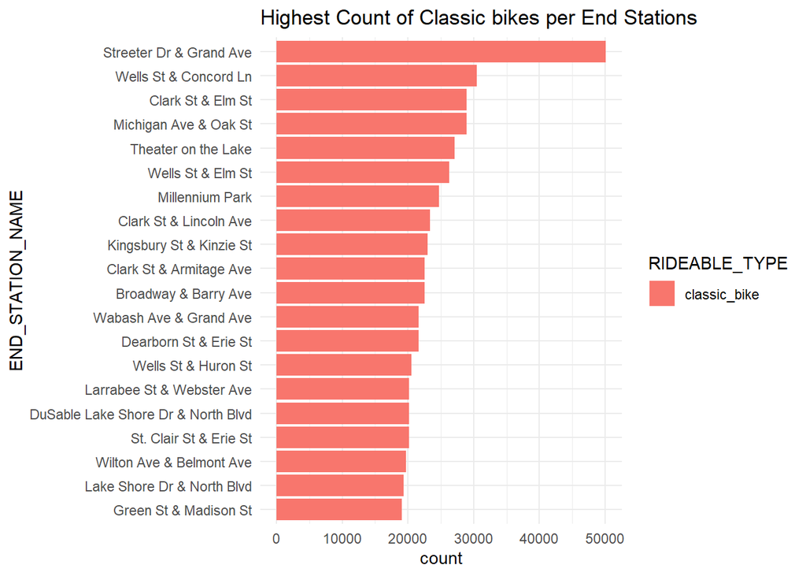

```r
print(head(endstationame_by_ridetype %>%
             filter(RIDEABLE_TYPE == "classic_bike") %>%
             mutate(END_STATION_NAME = reorder(END_STATION_NAME, count)), 20) %>%
        ggplot(aes(x = END_STATION_NAME, y = count, fill = RIDEABLE_TYPE)) +
        geom_col(position = "stack") +
        coord_flip() +
        ggtitle(label = "Highest Count of Classic bikes per End Stations" ) +
        theme_minimal())
```

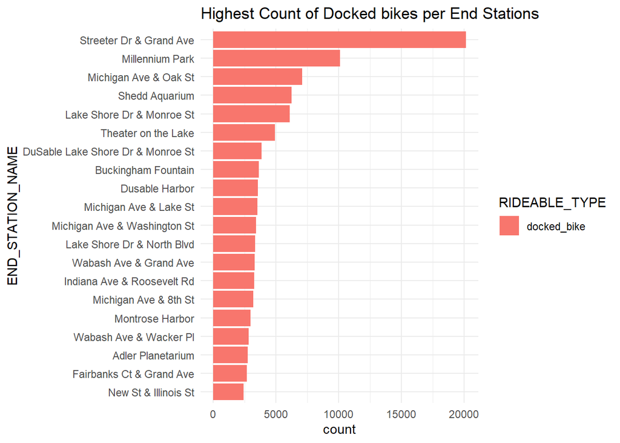

```r
print(head(endstationame_by_ridetype %>%
             filter(RIDEABLE_TYPE == "docked_bike") %>%
             mutate(END_STATION_NAME = reorder(END_STATION_NAME, count)), 20) %>%
        ggplot(aes(x = END_STATION_NAME, y = count, fill = RIDEABLE_TYPE)) +
        geom_col(position = "stack") +
        coord_flip() +
        ggtitle(label = "Highest Count of Docked bikes per End Stations" ) +
        theme_minimal())
```

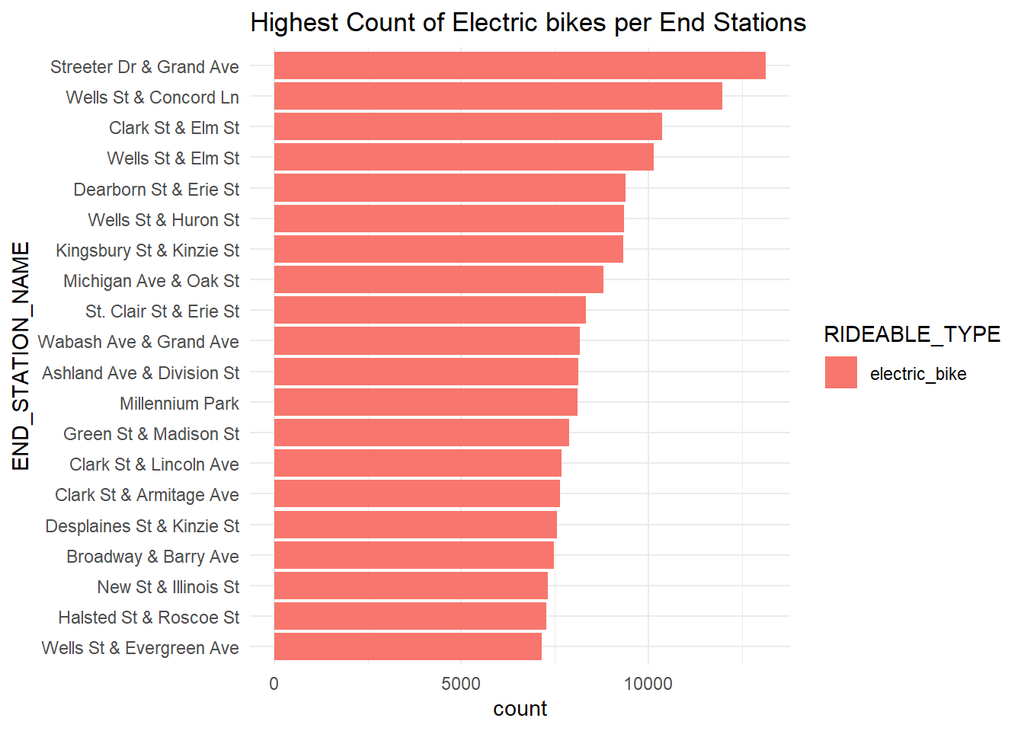

```r
print(head(endstationame_by_ridetype %>%
             filter(RIDEABLE_TYPE == "electric_bike") %>%
             mutate(END_STATION_NAME = reorder(END_STATION_NAME, count)), 20) %>%
        ggplot(aes(x = END_STATION_NAME, y = count, fill = RIDEABLE_TYPE)) +
        geom_col(position = "stack") +
        coord_flip() +
        ggtitle(label = "Highest Count of Electric bikes per End Stations" ) +
        theme_minimal())
```

Now, let’s see the relationship between number of user_type and Cyclistic bike end stations

#### Determine the end stations with the highest number of casual or annual users

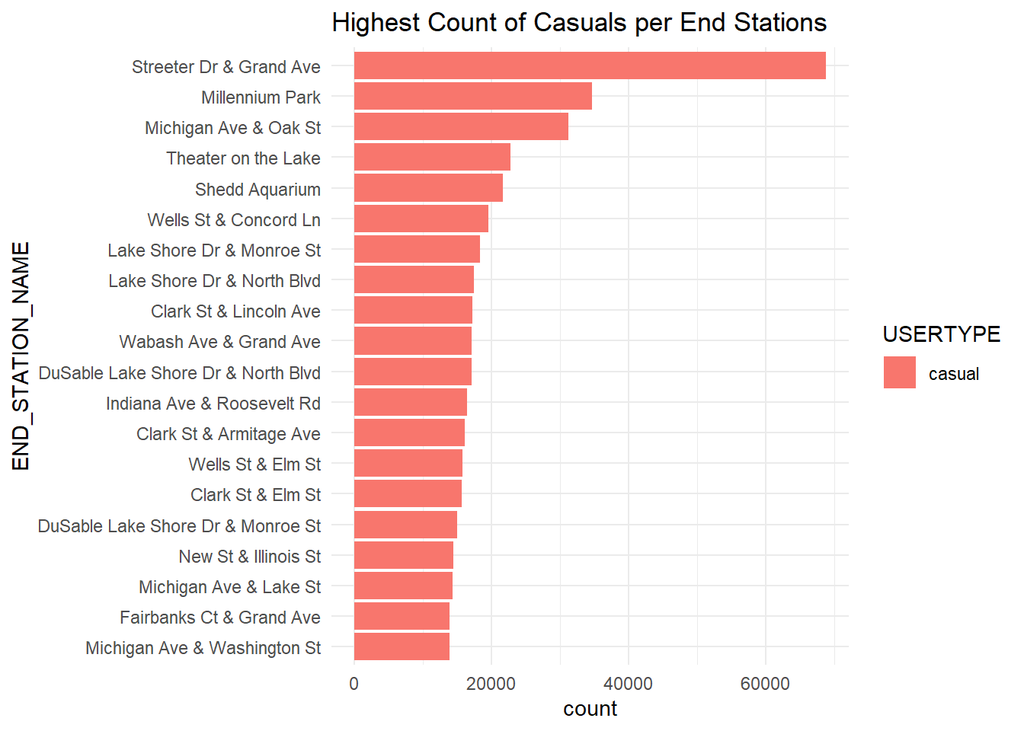

```r
print(head(endstationame_by_usertype %>%
             filter(USERTYPE == "casual") %>%
             mutate(END_STATION_NAME = reorder(END_STATION_NAME, count)),20) %>%
        ggplot(aes(x = END_STATION_NAME, y = count, fill = USERTYPE)) +
        geom_col(position = "stack") +
        coord_flip() +
        ggtitle(label = "Highest Count of Casuals per End Stations" ) +
        theme_minimal())
```

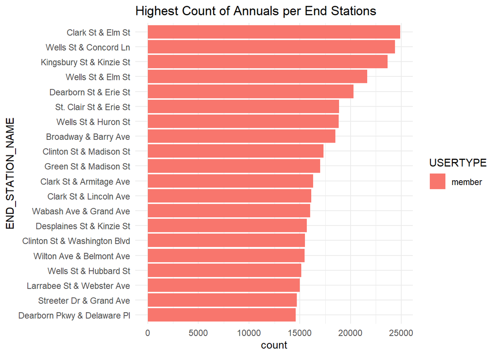

```r
print(head(endstationame_by_usertype %>%
             filter(USERTYPE == "member") %>%
             mutate(END_STATION_NAME = reorder(END_STATION_NAME, count)), 20) %>%
        ggplot(aes(x = END_STATION_NAME, y = count, fill = USERTYPE)) +
        geom_col(position = "stack") +
        coord_flip() +
        ggtitle(label = "Highest Count of Annuals per End Stations" ) +
        theme_minimal())
```

Notes:

1. From the result, we also observe same output with the end stations, having the highest count of classic_bikes, electric_bikes, and docked_bikes with **‘Streeter Dr & Grand Ave’**.
2. We also observe, from the plots above, that by comparing the counts of Casuals per end stations, we see that majority of casuals (**> 20,000**) are located closely to end stations where they have high counts of docked bikes. For example, *Streeter Dr & Grand Ave*, *Millennium Park*, *Shedd Aquarium*, *Theather on the Lake*, *Michigan Ave & Oak St*, etc.
3. Similarly, just as with start stations, we observe that by comparing the counts of Annuals per end stations, majority of Annuals (**> 20,000**) are located away from docked_bike end stations, but are found close to end stations with high counts of electric and classic bikes. For example, *Clark St & Elm St.*, *Wells St & Concord Ln*, *Kingsbury St & Kinzie St*, and *Wells St & Elm St*, etc.

   In general, while Casuals are located closely at areas in Chicago where there classic and electric bike stations, a large number of them are found patronizing station where there are high counts of docked bikes.

   Annuals are located closely at areas in Chicago where there are more classic and electric bikes stations, and little to no docked bikes station.

   Hence, this explain one reason why Casuals patronize the use of docked bikes than Annuals.